Special Article

Impact of high iron intake on cognition and neurodegeneration

in humans and in animal models: a systematic review

Sonal Agrawal, Kiersten L. Berggren, Eileen Marks, and Jonathan H. Fox

Context: Accumulation of brain iron is linked to aging and protein-misfolding

neurodegenerative diseases. High iron intake may influence important brain health

outcomes in later life. Objective: The aim of this systematic review was to examine

evidence from animal and human studies of the effects of high iron intake or pe-

ripheral iron status on adult cognition, brain aging, and neurodegeneration. Data

Sources: MEDLINE, Scopus, CAB Abstracts, the Cochrane Central Register of Clinical

Trials, and OpenGrey databases were searched. Study Selection: Studies investi-

gating the effect of elevated iron intake at all postnatal life stages in mammalian

models and humans on measures of adult brain health were included. Data

Extraction: Data were extracted and evaluated by two authors independently,

with discrepancies resolved by discussion. Neurodegenerative disease diagnosis

and/or behavioral/cognitive, biochemical, and brain morphologic findings were

used to study the effects of iron intake or peripheral iron status on brain health.

Risk of bias was assessed for animal and human studies. PRISMA guidelines for re-

porting systematic reviews were followed. Results: Thirty-four preclinical and 14

clinical studies were identified from database searches. Thirty-three preclinical stud-

ies provided evidence supporting an adverse effect of nutritionally relevant high

iron intake in neonates on brain-health-related outcomes in adults. Human studies

varied considerably in design, quality, and findings; none investigated the effects

of high iron intake in neonates/infants. Conclusions: Human studies are needed to

verify whether dietary iron intake levels used in neonates/infants to prevent iron de-

ficiency have effects on brain aging and neurodegenerative disease outcomes.

INTRODUCTION

Iron proteins have key roles in normal brain function

and the processes of brain development, including neu-

rogenesis, myelination, synaptic development, and en-

ergy and neurotransmitter metabolism.<sup>1</sup><sup>–</sup><sup>3</sup>The large

amount of iron required to perform these functions is

acquired from blood, mainly during periods of rapid

brain growth.<sup>4</sup>In adult life, iron uptake by the brain still

occurs, though at levels significantly lower than those

during development.<sup>5</sup>Iron levels in the brain can be al-

tered by peripheral iron levels and iron nutrition.

Effects of iron nutrition on the brain have been studied

extensively in iron deficiency, the leading nutrient

Affiliation: S. Agrawal and J.H. Fox are with the Department of Veterinary Sciences, University of Wyoming, Laramie, Wyoming, USA.

K.L. Berggren is with the Department of Radiation Oncology, University of New Mexico Cancer Center, Albuquerque, New Mexico, USA.

E. Marks is with the Department of Cellular and Integrative Physiology, University of Nebraska Medical Center, Omaha, Nebraska, USA.

Correspondence: J.H. Fox, Department of Veterinary Sciences, University of Wyoming, 1174 Snowy Range Rd, Laramie, WY 82070, USA.

Email: jfox7@uwyo.edu. Phone: þ1-307-766-9953.

Key words: brain aging, iron nutrition, iron supplementation, protein-misfolding neurodegenerative diseases.

V

C The Author(s) 2017. Published by Oxford University Press on behalf of the International Life Sciences Institute.

This is an Open Access article distributed under the terms of the Creative Commons Attribution-NonCommercial-NoDerivs licence (http://

creativecommons.org/licenses/by-nc-nd/4.0/), which permits non-commercial reproduction and distribution of the work, in any medium,

provided the original work is not altered or transformed in any way, and that the work properly cited. For commercial re-use, please con-

tact journals.permissions@oup.com.

doi: 10.1093/nutrit/nux015

456

Nutrition Reviews<sup>V</sup>

R Vol. 75(6):456–470

deficiency worldwide.<sup>6</sup>Iron deficiency during both de-

velopment and adulthood results in diverse effects on

neural function.<sup>7</sup><sup>–</sup><sup>9</sup>In contrast, the effects of high pe-

ripheral iron status on the brain are poorly understood.

The widespread use of iron-fortified foods, such as milk

replacers, other beverages, and solid foods, as well as

iron supplements has decreased the prevalence of defi-

ciency in all age groups in many populations. However,

iron-augmented diets also have the potential to increase

iron intake above levels needed to prevent deficiency.<sup>10</sup>

Brain aging and protein-misfolding neurodegenera-

tive diseases such as Alzheimer disease, Parkinson disease,

Huntington disease, and amyotrophic lateral sclerosis

share some common mechanisms.<sup>11</sup>Older age is the

greatest risk factor for the accumulation of misfolded pro-

teins that typifies the earliest stages of Alzheimer disease

and Parkinson disease.<sup>12</sup>Therefore, Alzheimer disease and

Parkinson disease may represent pathologic extensions of

normal processes of brain aging. Protein misfolding, pro-

tein accumulation, and neurodegeneration are also core

features of Huntington disease and amyotrophic lateral

sclerosis.<sup>13</sup><sup>,</sup><sup>14</sup>Accumulation of iron in the brain occurs

with human aging, and iron levels correlate with cognitive

function.<sup>15</sup><sup>,</sup><sup>16</sup>Iron accumulation in the brain also occurs

with Alzheimer disease, Parkinson disease, Huntington

disease, and amyotrophic lateral sclerosis.<sup>17</sup><sup>–</sup><sup>20</sup>Alzheimer

disease, Parkinson disease, and amyotrophic lateral sclero-

sis most commonly manifest as sporadic diseases.<sup>11</sup>They

are modeled in mice by mimicking the less-common ge-

netic forms of the human disease and/or by using toxi-

cants.<sup>21</sup><sup>–</sup><sup>23</sup>Huntington disease is caused by a single gene,

and several genetic mouse models exist.<sup>24</sup>

There is evidence from human and animal studies

that iron dysregulation is one factor that contributes to

the neurodegeneration associated with Alzheimer dis-

ease, Parkinson disease, Huntington disease, and amyo-

trophic lateral sclerosis.<sup>25</sup>In health, iron homeostatic

mechanisms maintain not only appropriate iron ab-

sorption and tissue levels but also cellular and subcellu-

lar location and molecular associations. Dysregulation

of these processes results in increased production of re-

active oxygen species, resulting in molecular damage,

mitochondrial dysfunction, and cell death.<sup>26</sup>Despite ev-

idence of a contributory role of iron in brain aging and

neurodegeneration, the role of elevated iron intake as a

modifier of these processes is poorly understood.<sup>15</sup><sup>–</sup><sup>20</sup>

Given the increasing life expectancy and the resulting

increased prevalence of neurodegenerative diseases,<sup>11</sup>it

is particularly important to understand the effects of

high iron intake at various life stages on brain aging.

Recommended Dietary Allowances for iron have

been developed to prevent iron deficiency, and upper lim-

its were established to avoid short-term adverse effects.<sup>27</sup>

Possible effects of long-term iron intake above the

Recommended Dietary Allowance on cognition, brain ag-

ing, and neurodegenerative processes are not understood.

Furthermore, there is evidence that some populations are

iron replete and have elevated iron stores.<sup>28</sup>The aim of

this study was to use the methods of systematic review to

investigate the effects of high iron intake or high periph-

eral iron status on adult cognition and outcomes of

protein-misfolding neurodegenerative diseases in both an-

imal models and humans. The findings support a role of

high iron intake as a negative modifier of brain health in

adults. They also highlight gaps in understanding both the

mechanisms involved and the translatability of findings in

animal models to humans.

METHODS

Review protocol

The systematic review was undertaken in accordance with

PRISMA (Preferred Reporting Items for Systematic re-

views and Meta-Analyses) guidelines.<sup>29</sup>A checklist ensur-

ing adherence to PRISMA guidelines is shown in Table S1

in the Supporting Information online. A written protocol

was not used.

Information sources

The following electronic databases were searched:

MEDLINE, Scopus, CAB Abstracts, the Cochrane

Central Register of Clinical Trials, and OpenGrey. A

computerized literature search was conducted to iden-

tify studies that had been published up to June 28, 2016.

Search strategies are shown in Appendix S1 in the

Supporting Information online.

Study eligibility criteria

Study inclusion and exclusion criteria and research

questions were developed using the PICOS (population,

intervention,

comparators,

outcome,

study

design)

model. Included were studies investigating the effect of

elevated iron intake at all postnatal life stages in mam-

malian models and humans on measures of adult brain

health. Neurologic status in animal models is evaluated

using a number of outcomes that include cognitive test-

ing; biochemical measurement of markers linked to

neurodegeneration, such as brain iron accumulation,

neurotransmitter levels, and oxidative stress markers;

and brain morphometry. Therefore, animal studies with

diverse outcome measures were included. Human stud-

ies included were those that estimated former or cur-

rent levels of iron intake or peripheral measures of iron

status and their effect on brain iron, cognition, and/or

the onset of neurodegenerative disease in adults. Details

Nutrition Reviews<sup>V</sup>

R Vol. 75(6):456–470

457

of the inclusion and exclusion criteria are provided in

Table 1.

Assessment of risk of publication bias in

preclinical studies

Comparing the number of studies reporting negative

findings in the unpublished versus the published literature

is one way to assess publication bias. Risk of publication

bias was assessed by one author (S.A.). The Society for

Neuroscience’s online database is a collection of abstracts

presented at annual meetings; the years 2007–2015 were

searched. Relevant abstracts were evaluated for the pres-

ence of positive or negative findings but were not included

as part of the review. Permission was obtained from the

Society for Neuroscience to access this private database.

Risk of bias

The quality of the included papers was assessed at the

study level. For animal studies, 7 indicators of quality

adapted from the National Research Council’s Institute

for Laboratory Animal Research were used<sup>30</sup><sup>,</sup><sup>31</sup>: (1) ran-

dom allocation of treatment, (2) allocation concealment,

(3) blinding, (4) stated inclusion/exclusion criteria, (5) test

animal details, (6) every animal accounted for, and (7)

conflict of interest statement and funding source. Human

cohort and case–control studies were analyzed using tools

from the Critical Appraisal Skills Program, while cross-

sectional studies were assessed using tools modified from

those recommended by the Agency for Healthcare

Research and Quality.<sup>32</sup>The criteria were assessed inde-

pendently by two reviewers (S.A. and J.H.F.); discrepan-

cies were resolved by discussion.

Data extraction and synthesis

Study characteristics and data were extracted and evalu-

ated by two authors independently (S.A. and J.H.F.),

with

discrepancies

resolved

by

discussion.

Meta-

analysis was not possible because of the heterogeneous

nature of the studies and the varied outcomes. Papers

were grouped into 4 themes: preclinical studies of the

effect of high iron intake on outcomes related to behav-

ior and brain aging (Table 2)<sup>33</sup><sup>–</sup><sup>51</sup>; preclinical studies of

the effect of high iron intake on outcomes related to

neurodegenerative disease (Table 3)<sup>52</sup><sup>–</sup><sup>66</sup>; human nutrition

studies assessing the association between iron intake

and brain outcomes (Table 4)<sup>67</sup><sup>–</sup><sup>72</sup>; and human stud-

ies assessing the association between peripheral iron

status and brain outcomes (Table 5).<sup>73</sup><sup>–</sup><sup>80</sup>Qualitative

synthesis of the included studies was completed

within and across the 4 themes. All findings reported

in Tables 2, 3, 4, and 5 are statistically significant un-

less otherwise stated.

RESULTS

Description of the included studies

A PRISMA flow chart showing papers included and ex-

cluded at each step is shown in (Figure 1). A total of

Table 1 PICOS criteria for inclusion and exclusion of studies

Category

Inclusion criteria

Exclusion criteria

Participants

Animal studies: mammals

Human studies: all races and both sexes

Animal studies: nonmammalian species

Human studies: hemochromatosis or neurologic

disease diagnosis before determination of iron

status or intake level

Intervention

Animal studies: oral administration of iron supplements

or high-iron diets

Human studies: iron supplementation or estimation of

iron intake or peripheral iron status at any age

Parenteral administration of iron

Toxic level of iron supplementation in animals

Studies of effects of maternal iron intake on progeny

Studies of iron supplementation in the context of

deficiency

Comparator

Control group for iron intake in animal and human

experimental studies

Human studies: sex and age matched, absence of

neurologic disease, lower natural iron intake or lower

peripheral iron status

None

Outcomes

Animal studies: behavior, brain biochemistry, and

neuropathology

Human studies: development of neurodegenerative

disease, markers of brain iron status, cognition

Animal and human studies: outcomes measured in

preadults

Study design

Experimental animal studies

Human studies: randomized controlled nutritional

studies, all types of observational studies

English language

Dated up to June 2016

Meta-analyses, reviews, gray literature, short commu-

nications, abstracts, and case reports

458

Nutrition Reviews<sup>V</sup>

R Vol. 75(6):456–470

Table 2 Preclinical studies evaluating the effect of high iron intake on outcomes related to behavior and brain aging

Reference

Sex/strain/species

Iron form and dosage

rangea

Age at iron supplementation

and at outcome measurement

Bias assessmentb

Major effects of iron supplementation

Fredriksson et al. (1999)41

Male NMRI mice

Ferrous succinate;

3.7–37 mg/kg

Iron: 10–12 d

Outcome: 3 mo

U, U, U, U, L, U, H

Supplementation produced deficits in

spontaneous activity and spatial learn-

ing. Iron levels in basal ganglia were in-

creased 22%–58%. No effect on frontal

cortical iron

Fredriksson et al. (2000)42

Male NMRI mice

Ferrous succinate;

7.5 mg/kg

Iron: 3–5 d, 10–12 d, and

19–21 d

Outcome: 3 mo

U, U, U, U, L, U, Lc

Supplementation on days 3–5 and 10–12

resulted in (1) deficits in spontaneous ac-

tivity and spatial learning and (2) a

26%–48% increase in basal ganglia iron

Isacc et al. (2006)43

Male C57 BL/6 mice

Ferrous succinate;

7.5 mg/kg

Iron: 10–12 d

Outcome: 3–4 mo

U, U, U, U, L, U, Lc

Iron-supplemented mice had decreases in

brain phosphatidyl choline and sphingo-

myelin levels

de Lima et al. (2005)49

Male Wistar rats

Ferrous succinate;

10 mg/kg

Iron: 5–7 d, 12–14 d, 19–21 d,

and 30–32 d

Outcome: 3 mo

U, U, U, U, L, U, Lc

Supplementation of iron on days 12–14 (1)

impaired object recognition by �36%

and (2) increased oxidative stress in hip-

pocampus and substantia nigra

Miwa et al. (2011)51

Male Wistar rats

Ferrous succinate;

10 mg/kg

Iron: 12–14 d

Outcome: 3–24 mo

U, U, U, U, L, U, Lc

Supplementation increased expression of

the apoptosis markers prostate apoptosis

response-4 and caspase-3 protein at

3 mo but decreased expression at 24 mo

Fernandez et al. (2011)39

Male Wistar rats

Ferrous succinate;

10 mg/kg

Iron: 12–14 d

Outcome: 3–24 mo

U, U, U, U, L, U, Lc

Iron supplementation induced mild astro-

cytosis in hippocampus at 3 mo and in

striatum and substantia nigra at 24 mo

Schroder et al. (2001)46

Male Wistar rats

Ferrous succinate;

2.5–30.0 mg/kg

Iron: 10–12 d

Outcome: 3–6 mo

U, U, U, U, L, U, Lc

Supplementation resulted in (1) dose-de-

pendent deficits in radial arm maze

learning and (2) a 46%–92% increase in

substantia nigra iron content

Figueiredo et al. (2016)40

Male Wistar rats

Carbonyl iron; 10 mg/kg

Iron: 12–14 d

Outcome: 3 mo

U, U, Ld, U, L, U, L

Iron supplementation (1) impaired emo-

tionally motivated behavior and recogni-

tion memory and (2) increased

hippocampal protein ubiquitination

Dornelles et al. (2010)38

Male Wistar rats

Ferrous succinate;

10 mg/kg

Iron: 12–14 d

Outcome: 3–24 mo

U, U, U, U, L, U, Lc

Supplementation changed expression of

mRNA encoding genes involved in iron

homeostasis in an age- and brain-re-

gion-specific manner

de Lima et al. (2005)35

Male Wistar rats

Ferrous succinate;

10 mg/kg

Iron: 12–14 d

Outcome: 3 mo

U, U, Ld, U, L, U, Lc

Monoamine oxidase inhibition protected

against behavioral effects of iron

supplementation

Budni et al. (2007)34

Male Wistar rats

Ferrous succinate;

10 mg/kg

Iron: 12–14 d

Outcome: 3 mo

U, U, U, U, L, U, Lc

Monoamine oxidase inhibition decreased

iron supplementation–induced oxidative

stress in substantia nigra and

hippocampus

(continued)

Nutrition Reviews<sup>V</sup>

R Vol. 75(6):456–470

459

Table 2 Continued

Reference

Sex/strain/species

Iron form and dosage

rangea

Age at iron supplementation

and at outcome measurement

Bias assessmentb

Major effects of iron supplementation

de Lima et al. (2008)37

Male Wistar rats

Ferrous succinate;

10 mg/kg

Iron: 12–14 d

Outcome: 3 mo

U, U, Ld, U, L, U, Lc

Type 4–specific phosphodiesterase inhibi-

tion protected against cognitive effects

of iron supplementation

de Lima et al. (2007)36

Male Wistar rats

Ferrous succinate;

10 mg/kg

Iron: 12–14 d

Outcome: 3 mo

U, U, U, U, L, U, Lc

Iron chelation with desferoxamine pro-

tected against behavioral effects of iron

supplementation

Rech et al. (2010)45

Male Wistar rats

Ferrous succinate;

10 mg/kg

Iron: 12–14 d

Outcome: 24 mo

U, U, U, U, L, U, Lc

No significant effect of neonatal iron sup-

plementation on motor activity or novel

object recognition

Fagherazzi et al. (2012)50

Male Wistar rats

Ferrous carbonyl;

10 mg/kg

Iron: 12–14 d

Outcome: 2.5 mo

L, U, Ld, U, L, U, Lc

Cannabidiol protected against deleterious

effects of neonatal iron supplementation

da Silva et al. (2014)47

Male Wistar rats

Iron carbonyl; 10 mg/kg

Iron: 12–14 d

Outcome: 3.5 mo

U, U, U, U, L, U, L

Cannabidiol normalized cortical caspase-3,

synaptophysin, and mitochondrial fission

dynamin-1-like protein

Perez et al. (2010)44

Male Wistar rats

Ferrous succinate;

10 mg/kg

Iron: 12–14 d

Outcome: 2–3 mo

U, U, U, U, L, U, Lc

Supplementation impaired long-term ob-

ject recognition (�28%) and decreased

striatal acetylcholinesterase activity

(�27%)

Silva et al. (2012)48

Male Wistar rats

Iron carbonyl; 10 mg/kg

Iron: 12–14 d

Outcome: 2 mo

U, U, Ld, U, L, U, Lc

Supplementation decreased object recog-

nition memory (�29%). Iron-induced

changes in histone acetylation in hippo-

campus were rescued with butyrate

Lavich et al. (2015)33

Male Wistar rats

Iron carbonyl; 10 mg/kg

Iron: 12–14 d

Outcome: 3 mo

U, U, Ld, U, L, U, L

Supplementation decreased novel object

recognition (�32%) and impaired mito-

chondrial dynamics. Effects of iron were

rescued with the antioxidant

sulforaphane

Abbreviations: H, high risk of bias; L, low risk of bias; U, unclear risk of bias.

aIron was delivered by gavage.

bLeft to right: random allocation of treatment, concealment of allocation, blinding, inclusion/exclusion criteria, test animal details, every animal accounted for, and conflicts of interest and

funding sources reported.

cOnly funding information was reported.

dOnly behavioral studies were blinded.

460

Nutrition Reviews<sup>V</sup>

R Vol. 75(6):456–470

Table 3 Preclinical studies evaluating the effect of high iron intake on outcomes related to neurodegenerative disease

Reference

Sex/strain/species/

disease modeled

Iron form and dosagea

Age(s) at supplementation

and at outcome

measurement

Bias assessmentb

Major effects of iron supplementation

Fredriksson et al. (2001)62

Male C57BL/6 mice; PD

Ferrous succinate; 7.5 mg/kg

Iron: 10–12 d

Outcome: 3–4 mo

U, U, U, U, L, U, Lc

Iron supplementation increased basal ganglia

iron by 72%. Supplementation and adult

neurotoxic MPTP treatment potentiated the

depletion of basal ganglia dopamine

Fredriksson et al. (2003)60

Male C57BL/6 mice; PD

Ferrous succinate;

2.5–7.5 mg/kg

Iron: 10–12 d

Outcome: 3–4 mo

U, U, U, U, L, U, H

Iron supplementation increased basal ganglia

iron up to 102%. N-methyl-D-aspartate an-

tagonist MK801 with L-DOPA partly rescued

motor effects of iron supplementation

Fredriksson & Archer (2003)52

Male NMRI and C57BL/6

mice; PD

Ferrous succinate;

2.5–37 mg/kg

Iron: 10–12 d

Outcome: 3–4 mo

U, U, U, U, U, U, Lc

Iron supplementation increased basal ganglia

iron by 58% and decreased motor activities.

MPTP potentiated effects of neonatal iron

supplementation

Kaur et al. (2007)63

Male C57BL/6 � D2

mice; PD

Iron carbonyl; 120 mg/kg

Iron: 10–17 d

Outcome: 2–24 mo

U, U, U, U, L, U, Lc

Iron supplementation decreased striatal dopa-

mine by up to �44%, decreased dopami-

nergic neurons in the substantia nigra by up

to �29%, and enhanced the neurotoxic

effects of MPTP

Peng et al. (2007)65

Male C57BL/6 mice; PD

Iron carbonyl; 120 mg/kg

Iron: 10–17 d

Outcome: 2–24 mo

U, U, U, U, L, U, H

Iron supplementation decreased dopaminergic

cells at 24 mo by �25%; the herbicide para-

quat potentiated this effect; a superoxide

dismutase/catalase mimetic provided some

protection

Archer & Fredriksson (2007)54

Male C57/BL6 mice; PD

Ferrous succinate; 7.5 mg/kg

Iron: 10–12 d

Outcome: 3 mo

U, U, U, U, L, U, H

Iron supplementation increased basal ganglia

iron by �67%. Neuroleptic agents modu-

lated behavioral effects of iron

Fredriksson & Archer (2006)61

Male C57/BL6 mice; PD

Ferrous succinate; 7.5 mg/kg

Iron: 10–12 d

Outcome: 3 mo

U, U, U, U, L, U, H

Neuroleptic agent haloperidol modulated the

behavioral effects of iron supplementation

Wang et al. (2014)53

Male Sprague-Dawley

rats; PD

Iron carbonyl; 120 mg/kg

Iron: 10–17 d

Outcome: 20 mo

U, U, U, U, L, U, Lc

Iron supplementation reduced motor activity

and decreased striatal dopamine by �38%.

Inhibition of sirtuin 2 provided some

protection

Peng et al. (2010)64

Male mutant a-synu-

clein mice (C57BL/

6 strain); PD

Iron carbonyl; 120 mg/kg

Iron: 10–17 d

Outcome: 12–23 mo

U, U, U, U, L, U, H

Interaction between mutant a-synuclein and

iron þ paraquat combination treatment

promoted loss of dopaminergic neurons

Dal-Pizzol et al. (2001)58

Male Wistar rats; PD

Ferrous succinate;

7.5–15 mg/kg

Iron: 10–12 d

Outcome: 3 mo

U, U, U, U, L, U, H

Neonatal iron supplementation increased

substantia nigra lipid peroxidation by

�48%–66%

Chen et al. (2015)57

Male/female Sprague-

Dawley rats; PD

Iron carbonyl; 120 mg/kg

Iron: 10–17 d

Outcome: 7–21 mo

U, U, U, U, L, U, L

Iron supplementation decreased motor activ-

ity, striatal dopamine (�35%), and substan-

tia nigra glutathione (�40%) and increased

nigral lipid peroxidation (�100%)

(continued)

Nutrition Reviews<sup>V</sup>

R Vol. 75(6):456–470

461

Table 3 Continued

Reference

Sex/strain/species/

disease modeled

Iron form and dosagea

Age(s) at supplementation

and at outcome

measurement

Bias assessmentb

Major effects of iron supplementation

Billings et al. (2016)56

Male a-synuclein trans-

genic mice (C57BL/6

strain); PD

Iron carbonyl; 120 mg/kg

Iron: 10–17 d

Outcome: 8 mo

U, U, U, U, L, U, Lc

Iron supplementation promoted loss of dopa-

minergic neurons in wild-type mice by

�30% but not in mutant a-synuclein trans-

genic mice

Fernandez et al. (2010)59

Male AbPP/PS1 trans-

genic mice; AD

Ferrous succinate; 10 mg/kg

Iron: 12–14 d

Outcome: 6 mo

U, U, U, U, U, U, L

Iron supplementation increased astrocytosis in

the cerebral cortex of transgenic and wild-

type mice. No effect of iron on amyloid

plaques

Berggren et al. (2015)55

Female R6/2 mice (B6/

CBA stain); HD

Iron carbonyl; 120 mg/kg for

neonates, 500 mg/kg for

adults

Iron: 10–17 d and 1–3 mo

(in feed)

Outcome: 3 mo

Ld, U, Le, U, L, U, Lc

Neonatal iron supplementation increased the

oxidative stress marker oxidized glutathione

(32%–53%) and neuronal atrophy

(13%–15%) in HD but not in wild-type

brains. There was no effect of iron

supplementation during adult life

Berggren et al. (2016)66

Female YAC128 HD

mice (FVB strain); HD

Iron carbonyl; 120 mg/kg for

neonates, 500 mg/kg for

adults

Iron: 10–17 d and 1–12 mo

(in feed)

Outcome: 12 mo

Ld, U, Ue, U, L, U, L

Neonatal iron supplementation promoted

striatal neuronal atrophy in HD mice (19%)

but not in wild-type littermates. There was

no effect of iron supplementation during

adult life

Abbreviations: AD, Alzheimer disease; H, high risk of bias; HD, Huntington disease; L, low risk of bias; L-DOPA, L-3,4-dihydroxyphenylalanine; MPTP, 1-methyl-4-phenyl-1,2,3,6-tetrahydropyri-

dine; PD, Parkinson disease; U, unclear risk of bias.

aIron was delivered by gavage to neonates and in feed to adults.

bLeft to right: random allocation of treatment, concealment of allocation, blinding, inclusion/exclusion criteria, test animal details, every animal accounted for, and conflicts of interest and

funding sources reported.

cOnly funding information was reported.

dWhole litters were randomized to receive iron supplementation.

eOnly histopathology studies were blinded.

462

Nutrition Reviews<sup>V</sup>

R Vol. 75(6):456–470

2531 potentially relevant articles were identified. After

screening titles and abstracts, 129 papers were identified

for full-text evaluation. After reviewing, 81 papers were

excluded. Of the 48 included papers, 34 described pre-

clinical studies. Nineteen of these focused primarily on

behavioral and age-related outcomes (Table 2), and 15

focused on outcomes related to neurodegenerative pro-

cesses (Table 3). Fourteen studies were conducted in

humans: 6 assessed associations between iron nutrition

and brain outcomes (Table 4), and 8 assessed associa-

tions between peripheral iron status and brain out-

comes (Table 5).

Assessment of risk of publication bias

After searching meeting abstracts from 9 years of the

Society for Neuroscience’s database, 5 studies were

found that addressed the role of elevated nutritional

iron intake in neurodegenerative processes, all in

animal models. All 5 abstracts described adverse effects

of elevated iron intake on brain outcomes.

Assessment of risk of bias in the included studies

Assessments of preclinical studies are presented in

Tables 2 and 3. Assessments of clinical studies are pre-

sented in Tables 6 and 7.

Preclinical studies of the effect of high iron intake on

behavior, brain aging, or neurodegeneration in

neonates or adults

Fifteen studies used a mouse model and 19 a rat

model. Five of the studies assessed the effect of ele-

vated iron intake in genetic models of adult-onset neu-

rodegenerative disease,<sup>55</sup><sup>,</sup><sup>56</sup><sup>,</sup><sup>59</sup><sup>,</sup><sup>64</sup><sup>,</sup><sup>66</sup>while the remainder

studied aging or neurodegenerative processes in wild-

type animals. All studies assessed the effect of elevated

Table 4 Human nutrition studies assessing the association between iron intake and brain outcomes

Reference

Study design

Population

Evaluation of dietary iron and

outcomes

Main findings

Anderson et al.

(1999)<sup>72</sup>

Case–control

103 newly diagnosed PD

patients and 156 controls;

WA, USA

In-person interview about diet,

covering most of adult life.

Risk of PD

Iron intake was not related

to increased PD risk

Powers et al.

(2003)<sup>71</sup>

Case–control

250 newly diagnosed PD

patients and 388 age- and

sex-matched controls; WA,

USA

In-person interview about diet,

covering most of adult life.

OR for risk of development

of PD for each quartile of

dietary factor

Subjects in highest quartile

of iron intake had in-

creased risk of PD com-

pared with those in lowest

quartile (OR 1.7)

Powers et al.

(2009)<sup>70</sup>

Case–control

420 patients (median age 69 y)

and 560 age-, sex-, and

ethnicity-matched controls

(median age, 71 y); USA

In-person interview about diet,

covering most of adult life.

Logistic regression used to

determine OR for the devel-

opment of PD for each level

of dietary factor

Men in highest quartile of

iron intake had increased

risk of PD compared with

those in lowest quartile

(OR 1.82)

Logroscino et al.

(2008)<sup>69</sup>

Cohort

47 406 men and 46 947

women, all health

professionals; USA

FFQ every 4 y of study.

Outcome of PD as

determined by neurologist

Increased intake of nonheme

iron but not total iron is a

risk for PD (relative

risk ¼ 1.27 and 1.1,

respectively)

Hernandez Mdel

et al. (2015)<sup>68</sup>

Cohort

1063 healthy, older,

community-dwelling men

and women, mean age 73 y;

UK

Self-reported food question-

naire validated in older

adults. Brain iron deposits

determined by MRI in brain-

stem, white matter, thala-

mus, basal ganglia, and

cortex. Blood iron markers

ferritin and transferrin

determined

Iron intake did not correlate

with blood or brain iron

measurements. Brain iron

deposits did not correlate

with blood iron

measurements

Hagemeier et al.

(2015)<sup>67</sup>

Cohort

190 healthy men and women,

mean age 43 y, USA

Historic (3 y) nutritional

questionnaire assessing

consumption of iron, cal-

cium, vegetables, dairy,

and red meat. Brain iron

determined by MRI in basal

ganglia, thalamus, and

substantia nigra

Trend toward increased brain

iron with iron supplemen-

tation (P ¼ 0.075). Effects

were dependent on sex

Abbreviations: FFQ, food frequency questionnaire; MRI, magnetic resonance imaging; OR, odds ratio; PD, Parkinson disease.

Nutrition Reviews<sup>V</sup>

R Vol. 75(6):456–470

463

neonatal iron intake. Levels of daily iron supplementa-

tion ranged from 2.5 to 120 mg/kg over a period of 3

to 8 days. All studies except one<sup>45</sup>provided evidence

of adverse effects of increased neonatal iron intake on

neurologic outcomes. Many of the studies assessed be-

havioral outcomes only. Sixteen studies evaluated mo-

tor outcomes such as open-field and/or rota-rod

endurance. Of these, 13 found altered motor behav-

iors,<sup>41</sup><sup>–</sup><sup>43</sup><sup>,</sup><sup>46</sup><sup>,</sup><sup>52</sup><sup>–</sup><sup>57</sup><sup>,</sup><sup>60</sup><sup>–</sup><sup>62</sup>and 3 did not.<sup>33</sup><sup>,</sup><sup>45</sup><sup>,</sup><sup>66</sup>Results

from memory-based tests such as novel object recogni-

tion and/or radial-arm maze were presented in 13

studies.<sup>33</sup><sup>,</sup><sup>35</sup><sup>–</sup><sup>37</sup><sup>,</sup><sup>40</sup><sup>–</sup><sup>42</sup><sup>,</sup><sup>44</sup><sup>–</sup><sup>46</sup><sup>,</sup><sup>48</sup><sup>–</sup><sup>50</sup>

Brain regional biochemical analyses in the 34 pre-

clinical studies most frequently investigated oxidative

stress, neurochemical markers, or iron levels. Markers

of brain oxidative stress, including malondialdehyde

and protein carbonyls, were increased in 9 stud-

of neonatal iron intake on brain neurochemistry out-

comes. Three of these studies reported decreased striatal

dopamine in adult animals,<sup>53</sup><sup>,</sup><sup>57</sup><sup>,</sup><sup>63</sup>while 2 found no ef-

fect on dopamine.<sup>60</sup><sup>,</sup><sup>62</sup>One study demonstrated de-

creased

striatal

acetylcholinesterase

activity,<sup>44</sup>

and

another found no effect on striatal serotonin.<sup>57</sup>Ten

studies reported increased brain iron after neonatal

supplementation.<sup>41</sup><sup>,</sup><sup>42</sup><sup>,</sup><sup>46</sup><sup>,</sup><sup>52</sup><sup>,</sup><sup>54</sup><sup>,</sup><sup>56</sup><sup>,</sup><sup>60</sup><sup>–</sup><sup>63</sup>Iron levels were ele-

vated in the substantia nigra in 3 of 3 studies, in the

basal ganglia in 6 of 7 studies, and in the cerebral cortex

in 1 of 8 studies. Two studies found no effect of neona-

tal iron supplementation on iron levels in the striatum

and cortex.<sup>55</sup><sup>,</sup><sup>66</sup>Six studies used quantitative pathology

to evaluate morphometric changes in the brain; these

demonstrated significantly decreased neuronal numbers

or neuronal cell body atrophy in specific brain re-

gions.<sup>55</sup><sup>,</sup><sup>56</sup><sup>,</sup><sup>63</sup><sup>–</sup><sup>66</sup>Overall, significant adverse effects of

neonatal iron intake on morphologic or biochemical

outcomes in specific brain regions were found in the

Table 5 Human studies assessing the association between peripheral iron status and brain outcomes

Reference

Study type

Population

Peripheral iron measures and

brain outcome(s)

Main findings

Gao et al. (2008)<sup>79</sup>

Cross-sectional

2000 men and women, >65 y,

rural areas; China

Plasma iron

Cognitive assessment

Plasma iron was not corre-

lated with cognitive scores

Lam et al. (2008)<sup>80</sup>

Cross-sectional

1451 men and women, all

ambulatory, mean age 75 y;

USA

Plasma iron

Cognitive assessment

Low and high (men) or high

(women) plasma iron asso-

ciated with poorer perfor-

mance in a battery of

cognitive tests

Milward et al.

(2010)<sup>77</sup>

Cohort

800 community-dwelling

adults, >60 y; Australia

Serum iron, transferrin satura-

tion, and ferritin measured

twice, 9 y apart

Cognitive assessment in year 9

No relationships found

between iron measures

and cognitive scores

Schiepers et al.

(2010)<sup>78</sup>

Cohort

818 adults, 50–70 y (mean

age 60 y); Netherlands

Total serum iron, total iron-

binding capacity, transferrin

saturation, and ferritin

Cognitive assessment

Measurements taken at base-

line and 3 y

Peripheral iron measures

were not associated with

cognitive outcomes

Umur et al.

(2011)<sup>75</sup>

Cross-sectional

87 nursing home residents,

>65 y, both sexes, no

neurologic diagnoses;

Turkey

Serum iron, transferrin satura-

tion, and ferritin

Mini-mental status

examination

Mild CI was associated with

significantly higher serum

iron (98%), ferritin (58%),

and transferrin saturation

(107%)

Mueller et al.

(2012)<sup>76</sup>

Case–control

19 controls, 11 cases of stable

mild CI, 7 cases of progres-

sive CI, and 19 cases of early

dementia; mean age �78 y;

USA

Serum copper and nonheme

iron

Cognitive testing every 6 mo

for 5 y

Ratio of serum copper to

nonheme iron increased

during the progression

from mild CI to Alzheimer

disease. No change in

nonheme iron

Andreeva et al.

(2013)<sup>74</sup>

Cohort

4959 men and women,

35–60 y; France

Hemoglobin determined in

year 1; serum ferritin deter-

mined in years 1 and 6

Cognitive outcomes evaluated

at year 13

Lower serum ferritin was as-

sociated with better out-

comes of some cognitive

measures in pre- and peri-

menopausal women

Blasco et al.

(2014)<sup>73</sup>

Cross-sectional

23 obese and 20 nonobese

individuals, both sexes,

mean age �49 y; Spain

Regional liver and brain iron

measured by MRI R2*

relaxation

Obese individuals had signifi-

cantly increased regional

liver and brain iron load

Abbreviations: CI, cognitive impairment; MRI, magnetic resonance imaging.

464

Nutrition Reviews<sup>V</sup>

R Vol. 75(6):456–470

substantia nigra (11 of 11 studies), the basal ganglia

(16 of 18 studies), the hippocampus (11 of 12 studies),

and the cerebral cortex (6 of 13 studies). Two studies,

in addition to assessing the effects of increased iron

intake in neonates, also evaluated the effect of elevated

iron intake in adult life; no effects in young adult or

aged wild-type and Huntington disease mice were

found.<sup>55</sup><sup>,</sup><sup>66</sup>

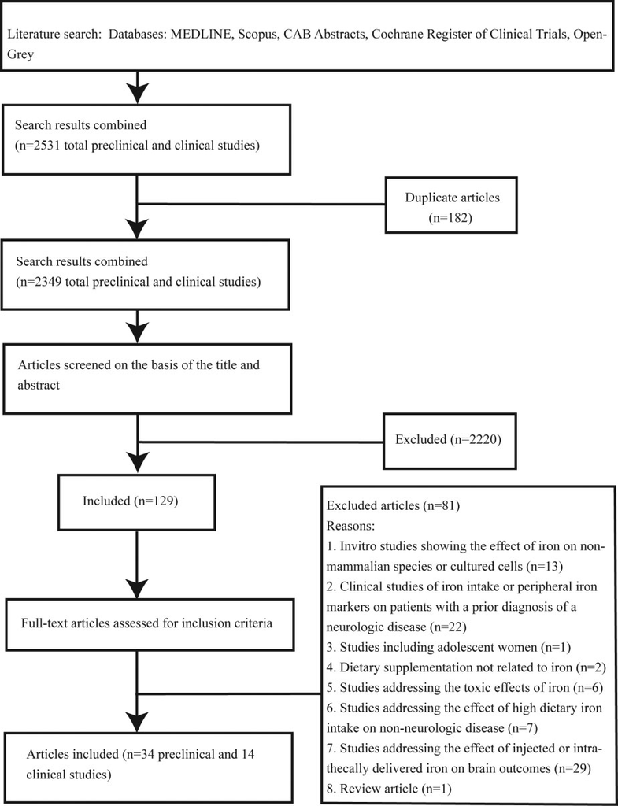

Figure 1 Flow diagram of the literature search process.

Nutrition Reviews<sup>V</sup>

R Vol. 75(6):456–470

465

Human studies assessing the correlation between iron

nutrition or iron status markers and brain outcomes

Fourteen studies fulfilled the inclusion criteria in assess-

ing the potential correlation between iron nutrition or

peripheral markers of iron nutrition and brain-related

outcomes. Six studies had the primary purpose of exam-

ining the association between estimates of iron intake

and brain iron accumulation or risk of Parkinson dis-

ease.<sup>67</sup><sup>–</sup><sup>72</sup>Of these, 2 cohort studies looked for associa-

tions between iron intake and brain iron deposits. One

was a large study in the United Kingdom that failed to

find a correlation between recent iron intake and mag-

netic resonance imaging (MRI) measures of brain iron

deposition in healthy older individuals.<sup>68</sup>Another

smaller study in the United States in middle-aged indi-

viduals demonstrated a trend (P ¼ 0.075) toward in-

creased

MRI-measured

brain

iron

with

iron

supplementation.<sup>67</sup>Four studies investigated possible

associations between iron intake and Parkinson dis-

ease.<sup>69</sup><sup>–</sup><sup>72</sup>Three of these had a case–control design and

recruited study subjects from the state of Washington,

USA. The initial smaller study did not find an associa-

tion between iron intake over most of adult life and the

risk of Parkinson disease.<sup>72</sup>Two subsequent larger stud-

ies provided some evidence of an association between

increased iron intake and risk of Parkinson disease.<sup>70</sup><sup>,</sup><sup>71</sup>

The fourth study had a cohort design and was very large

(94 353 subjects).<sup>69</sup>The authors concluded that in-

creased nonheme iron intake is a risk factor for

Parkinson disease, especially when ascorbate deficiency

is present.

Eight studies had the primary purpose of determin-

ing the presence of associations between peripheral iron

status and cognitive or other brain outcomes.<sup>73</sup><sup>–</sup><sup>80</sup>Four

of these had a cross-sectional design.<sup>73</sup><sup>,</sup><sup>75</sup><sup>,</sup><sup>79</sup><sup>,</sup><sup>80</sup>Three of

these reported significant associations of iron levels

with brain outcomes.<sup>73</sup><sup>,</sup><sup>75</sup><sup>,</sup><sup>80</sup>One large study of 1451

older individuals in the United States reported that high

plasma iron levels correlated with poorer cognitive out-

comes in both men and women.<sup>80</sup>

A much smaller study of 87 nursing home residents

in Turkey reported that high serum iron, ferritin, and

transferrin saturation were correlated with mild cogni-

tive impairment.<sup>75</sup>Another small Spanish study of 23

obese and 20 nonobese middle-aged individuals found

that MRI-measured brain and liver iron was elevated in

obese individuals.<sup>73</sup>One study of 2000 elderly individ-

uals from rural areas of China reported no correlation

between plasma iron and cognitive scores.<sup>79</sup>Three stud-

ies used a cohort design.<sup>74</sup><sup>,</sup><sup>77</sup><sup>,</sup><sup>78</sup>A study of 800 older

adults in Australia found no correlation between serum

iron, transferrin saturation, or ferritin levels and cogni-

tive outcomes.<sup>77</sup>One French study of 4959 middle-aged

Table 6 Risk-of-bias assessment for human studies assessing associations between iron nutrition and brain outcomes

Reference

Was the research

question focused?

Were appropriate

methods used?

Was case or

cohort

recruitment

acceptable?

Was control

recruitment

acceptable?

Did iron intake

estimates minimize

bias?

Were outcomes

measured to

minimize bias?

Were confounding

factors

accounted for?

Was subject

follow-up

complete?

Are the key

results

precise?

Are the

results

believable?

Anderson et al (1999)72

No

Yes

Yes

Yes

Yes

NA

Yes

NA

No

Yes

Powers et al (2003)71

No

Yes

Yes

Yes

Yes

NA

Yes

NA

Yes

Yes

Powers et al (2009)70

No

Yes

Yes

Yes

Yes

NA

Yes

NA

Yes

Yes

Logroscino et al (2008)69

Yes

Yes

Yes

NA

Yes

Yes

Yes

Yes

Yes

Yes

Hernandez Mdel et al

(2015)68

Yes

Noa

Yes

NA

Yes

Yes

Yes

Yes

No

Yes

Hagemeier et al (2015)67

Yes

Yes

Yes

NA

Yes

Yes

Yes

Yes

Yes

Yes

Abbreviation: NA, not applicable for study.

aThe timing and the period of dietary intake analysis were not optimal. Unclear inclusion and exclusion criteria.

466

Nutrition Reviews<sup>V</sup>

R Vol. 75(6):456–470

individuals reported associations between lower serum

ferritin and better cognitive outcomes, but only in pre-

and perimenopausal women.<sup>74</sup>A Netherlands-based

study of 818 middle-aged and older individuals found

no evidence of an association between peripheral mea-

sures of iron and cognitive performance.<sup>78</sup>Finally, a

during the progression from mild cognitive impairment

to Alzheimer disease.<sup>76</sup>

DISCUSSION

This systematic review examined evidence from animal

and human studies that investigated whether high iron

intake or markers of iron status correlated with cogni-

tive decline or the onset/progression of neurodegenera-

tive disease. Almost all the animal studies assessed the

effects of elevated iron intake in neonatal life on out-

comes in early to late adult life. These studies over-

whelmingly

demonstrated

adverse

effects

of

high

neonatal iron intake on diverse behavioral, brain mor-

phologic, and biochemical outcomes. In striking con-

trast, none of the human studies assessed the effects of

high iron intake in early life on adult cognitive or brain

iron outcomes.

There is substantial evidence that early-life envi-

ronmental factors, including nutrition, influence brain

development, which may then impact susceptibility to

brain aging or neurodegenerative processes in later

life.<sup>81</sup>Since brain iron accumulation is linked to aging

and neurodegenerative processes, it is important to un-

derstand the effects of high iron intake at various life

stages on the human brain. Preclinical studies evaluated

the effects of neonatal iron intake on outcomes related

to behavior and aging processes (Table 2) and on neu-

rodegenerative processes in wild-type and genetically

modified animals (Table 3). None of the studies fulfilled

all the methodological criteria for quality. Although the

strength of many studies was weakened by underreport-

ing of methodological details, all but 1 preclinical

study<sup>45</sup>(Table 2) provided evidence that elevated iron

intake in early life adversely affects cognition in adult

rodents. Although outcomes in early adult life were

studied most frequently, iron supplementation did in-

crease brain regional iron levels, a marker of brain ag-

ing.<sup>15</sup><sup>,</sup><sup>16</sup>Studies focused on neurodegenerative disease

outcomes (Table 3) also provide evidence that neonatal

iron supplementation promotes age-dependent progres-

sive neurodegeneration in the substantia nigra, the

main area of brain degeneration in Parkinson dis-

ease.<sup>53</sup><sup>,</sup><sup>57</sup><sup>,</sup><sup>63</sup><sup>–</sup><sup>65</sup>Preclinical studies investigating interac-

tions

between

neonatal

iron

nutrition

and

gene

mutations causing neurodegeneration showed evidence

Table 7 Risk-of-bias assessment for human studies assessing associations between peripheral iron status and brain outcomes

Reference

Was the

research

question

focused?

Were

appropriate

methods

used?

Was case or cohort

recruitment

acceptable?

Was control

recruitment

acceptable?

Was iron status

estimated to

minimize

bias?

Were outcomes

measured to

minimize bias?

Were confounding

factors accounted for?

Was subject

follow-up

complete?

Are the key

results precise?

Are the results

believable?

Gao et al (2008)79

Yes

Yes

Yes

NA

Yes

Yes

Yes

NA

Yes

Yes

Lam et al (2008)80

Yes

Yes

Ua

NA

Yes

Yes

Yes

NA

Yes

Yes

Milward et al (2010)77

Yes

Ub

Yes

NA

Yes

Yes

Yes

Yes

Yes

Yes

Schiepers et al (2010)78

Yes

Yes

Yes

NA

Yes

Yes

Yes

Yes

Yes

Yes

Umur et al (2011)75

Yes

Yes

Yes

NA

Yes

Yes

Yes

NA

Yes

Yes

Mueller et al (2012)76

Yes

Yes

Yes

Yes

Yes

Yes

No

Yes

Yes

Noc

Andreeva et al (2013)74

Yes

Ub

Yes

NA

Yes

Yes

Yes

Yes

Yes

Yes

Blasco et al (2014)73

Yes

Yes

Yes

NA

Yes

Yes

No

NA

Yes

Nod

Abbreviations: NA, not applicable for study; U, unclear inclusion and exclusion criteria.

aInclusion and exclusion criteria unclear.

bLack of controls to measure cognition at baseline.

cSmall group sizes (n ¼ 18–19).

dSmall group sizes (n ¼ 20–23).

Nutrition Reviews<sup>V</sup>

R Vol. 75(6):456–470

467

of synergism between iron intake and genetic disease

factors, although the number of studies was small.<sup>55</sup><sup>,</sup><sup>64</sup><sup>,</sup><sup>66</sup>

These findings suggest that individuals with gene muta-

tions

causing

protein-misfolding

neurodegenerative

diseases may have increased susceptibility to the adverse

effects of high iron intake in early life.

Exactly how the effects of neonatal iron intake in

mice translate to humans is unclear. The form and the

dose of iron supplementation are key factors affecting

the interpretation of preclinical studies. Soluble ferrous

succinate and insoluble iron carbonyl were used in the

included preclinical studies; both forms are used for hu-

man supplementation. There was considerable variation

in the daily dose of iron used in the neonatal iron sup-

plementation studies. The highest dose of 120 mg/kg

was used only with iron carbonyl, which has less bio-

availability than ferrous salts.<sup>82</sup>This highest level of

supplementation in mice is estimated to result in an ap-

proximate 40-fold increase over the iron present in nat-

ural milk. Human infants fed iron-fortified formula

have an iron intake level of up to 14 mg/d, which is also

about

40-fold

the

intake

level

of

breastfed

in-

fants.<sup>41</sup><sup>,</sup><sup>63</sup><sup>,</sup><sup>83</sup><sup>–</sup><sup>85</sup>Therefore, when translating iron dose on

a milligram-per-kilogram (mg/kg) basis from rodents

to humans, the highest levels of supplementation used

in the preclinical studies appear relevant to human

nutrition.

All of the included human studies assessed the ef-

fect of adult-life iron intake or iron status on brain out-

comes. These studies varied considerably in design,

size, and outcomes measures. Study qualities were gen-

erally good (Tables 6 and 7). However, not surprisingly,

results varied widely (Tables 4 and 5). Several of the hu-

man studies used Parkinson disease as their outcome,

which is not surprising, given the evidence of an associ-

ation between substantia nigra iron accumulation and

Parkinson disease.<sup>86</sup>The most complete iron nutrition

study, based on the large number of subjects, the pro-

spective study design, and the repeated food question-

naire analysis performed every 4 years, was that of

Logroscino et al.<sup>69</sup>(Table 4). These authors concluded

that increased nonheme iron intake is a risk for

Parkinson disease, especially when concurrent ascor-

bate deficiency is present. The literature searches con-

ducted for the present review, however, did not identify

any preclinical studies evaluating the effect of high iron

intake in adult life on Parkinson disease outcomes in

animal models. Preclinical studies that use varied out-

comes would inform the need for additional human

adult iron-nutrition studies assessing the risk for

Parkinson disease development. Most studies evaluating

A weakness of the studies investigating blood iron

status is that comprehensive measures of peripheral

iron status were frequently not used. Furthermore, al-

though some studies accounted for confounding fac-

tors, many did not account for the presence of

inflammatory disease, which influences iron status.<sup>87</sup><sup>,</sup><sup>88</sup>

CONCLUSION

When the results of animal studies are combined, there

is moderately strong evidence that nutritionally relevant

levels of high iron intake during early postnatal life

have adverse effects on the adult brain. Future preclini-

cal studies could focus on improving the understanding

of how high neonatal iron intake impacts the brain in

adult life. Thus far, human studies of the effects of high

iron intake on cognition and risk of disease do not

strengthen these preclinical findings because they have

investigated the effects of iron intake only in adult life.

There are significant challenges, such as cost and time,

when conducting prospective studies to examine the ef-

fects of early-life high iron intake on adult cognition

and brain aging processes. Retrospective studies are also

challenging because of the potential for recall bias.

Nevertheless, the need for human studies in this area

is supported by the preclinical findings reported in

the literature. Human studies should assess factors

besides nutrition that influence iron status, such as

physiologic blood loss, gene polymorphisms, and the

presence of inflammatory disease processes to better

determine the role of iron nutrition on the outcomes

investigated.

Acknowledgments

The authors thank Paul Troxell at the Society for

Neuroscience for access to the abstract database and

Jenny Garcia, University of Wyoming Coe Library, for

guidance with the database searches.

Author contributions. K.L.B. and E.M. completed an ini-

tial literature search and analysis which defined the

focus of the review. J.H.F. and S.A. designed the final

searches, screened the papers for inclusion, extracted

and summarized data, and completed methodological

assessments. All authors contributed to writing and

reviewing the manuscript and read and approved the

submitted version.

Funding/support. This work was supported by a grant from

the National Institutes of Health (NIH RO1 NS079450).

Declaration of interest. The authors have no relevant

interests to declare.

468

Nutrition Reviews<sup>V</sup>

R Vol. 75(6):456–470

Supporting Information

The following Supporting Information is available

through the online version of this article at the publish-

er’s website.

Appendix S1 Online search strategies for preclini-

cal and clinical studies

Table S1 Preferred reporting items for systematic

reviews or meta-analyses: the PRISMA statement

REFERENCES

1.

Wu LL, Zhang L, Shao J, et al. Effect of perinatal iron deficiency on myelination

and associated behaviors in rat pups. Behav Brain Res. 2008;188:263–270.

2.

Brunette KE, Tran PV, Wobken JD, et al. Gestational and neonatal iron deficiency

alters apical dendrite structure of CA1 pyramidal neurons in adult rat hippocam-

pus. Dev Neurosci. 2010;32:238–248.

3.

Daubner SC, Le T, Wang S. Tyrosine hydroxylase and regulation of dopamine syn-

thesis. Arch Biochem Biophys. 2011;508:1–12.

4.

Holmes-Hampton GP, Chakrabarti M, Cockrell AL, et al. Changing iron content of

the mouse brain during development. Metallomics. 2012;4:761–770.

5.

Chen JH, Shahnavas S, Singh N, et al. Stable iron isotope tracing reveals significant

brain iron uptake in adult rats. Metallomics. 2013;5:167–173.

6.

Baltussen R, Knai C, Sharan M. Iron fortification and iron supplementation are

cost-effective interventions to reduce iron deficiency in four subregions of the

world. J Nutr. 2004;134:2678–2684.

7.

Murray-Kolb LE, Beard JL. Iron treatment normalizes cognitive functioning in

young women. Am J Clin Nutr. 2007;85:778–787.

8.

Scott SP, Murray-Kolb LE. Iron status is associated with performance on executive

functioning tasks in nonanemic young women. J Nutr. 2016;146:30–37.

9.

Lozoff B, Beard J, Connor J, et al. Long-lasting neural and behavioral effects of iron

deficiency in infancy. Nutr Rev. 2006;64(5 pt 2):S34–S43; discussion S72–S91.

10.

Bailey RL, Gahche JJ, Lentino CV, et al. Dietary supplement use in the United

States, 2003–2006. J Nutr. 2011;141:261–266.

11.

Hardiman O, Doherty CP, eds. Neurodegenerative Disorders: A Clinical Guide.

London, UK: Springer; 2011.

12.

Thal DR, Del Tredici K, Braak H. Neurodegeneration in normal brain aging and

disease. Sci Aging Knowledge Environ. 2004;2004:pe26. doi:10.1126/sageke.

2004.23.pe26.

13.

DiFiglia M, Sapp E, Chase KO, et al. Aggregation of huntingtin in neuronal

intranuclear

inclusions

and

dystrophic

neurites

in

brain.

Science.

1997;277:1990–1993.

14.

Guerrero EN, Wang H, Mitra J, et al. TDP-43/FUS in motor neuron disease: com-

plexity and challenges. Prog Neurobiol. 2016;145–146:78–97.

15.

Hallgren B, Sourander P. The effect of age on the non-haemin iron in the human

brain. J Neurochem. 1958;3:41–51.

16.

Ghadery C, Pirpamer L, Hofer E, et al. R2* mapping for brain iron: associations

with cognition in normal aging. Neurobiol Aging. 2015;36:925–932.

17.

Raven EP, Lu PH, Tishler TA, et al. Increased iron levels and decreased tissue integ-

rity in hippocampus of Alzheimer’s disease detected in vivo with magnetic reso-

nance imaging. J Alzheimers Dis. 2013;37:127–136.

18.

He N, Ling H, Ding B, et al. Region-specific disturbed iron distribution in early idio-

pathic Parkinson’s disease measured by quantitative susceptibility mapping. Hum

Brain Mapp. 2015;36:4407–4420.

19.

Rosas HD, Chen YI, Doros G, et al. Alterations in brain transition metals in Huntington

disease: an evolving and intricate story. Arch Neurol. 2012;69:887–893.

20.

Ignjatovic A, Stevic Z, Lavrnic S, et al. Brain iron MRI: a biomarker for amyotrophic

lateral sclerosis. J Magn Reson Imaging. 2013;38:1472–1479.

21.

Elder GA, Gama Sosa MA, De Gasperi R. Transgenic mouse models of Alzheimer’s

disease. Mt Sinai J Med. 2010;77:69–81.

22.

Duty S, Jenner P. Animal models of Parkinson’s disease: a source of novel treat-

ments and clues to the cause of the disease. Br J Pharmacol. 2011;164:1357–1391.

23.

Philips T, Rothstein JD. Rodent models of amyotrophic lateral sclerosis. Curr

Protoc Pharmacol. 2015;69:5.67.1–5.67.21.

24.

Ferrante RJ. Mouse models of Huntington’s disease and methodological consider-

ations for therapeutic trials. Biochim Biophys Acta. 2009;1792:506–520.

25.

Li K, Reichmann H. Role of iron in neurodegenerative diseases. J Neural Transm

(Vienna). 2016;123:389–399.

26.

Nunez MT, Urrutia P, Mena N, et al. Iron toxicity in neurodegeneration. Biometals.

2012;25:761–776.

27.

Food and Nutrition Board, Institute of Medicine. Dietary Reference Intakes for

Vitamin A, Vitamin K, Arsenic, Boron, Chromium, Copper, Iodine, Iron, Manganese,

Molybdenum, Nickel, Silicon, Vanadium and Zinc. Washington, DC: National

Academy Press; 2001.

28.

Fleming DJ, Jacques PF, Tucker KL, et al. Iron status of the free-living, elderly

Framingham Heart Study cohort: an iron-replete population with a high preva-

lence of elevated iron stores. Am J Clin Nutr. 2001;73:638–646.

29.

Moher D, Liberati A, Tetzlaff J, et al. Preferred reporting items for systematic re-

views and meta-analyses: the PRISMA statement. PLoS Med. 2009;6:e1000097.

doi:10.1371/journal.pmed.1000097.

30.

Institute for Laboratory Animal Research, National Research Council. Guidance for

the Description of Animal Research in Animal Research in Scientific Publications.

Washington, DC: National Academies Press; 2011.

31.

Krauth D, Woodruff TJ, Bero L. Instruments for assessing risk of bias and other

methodological criteria of published animal studies: a systematic review. Environ

Health Perspect. 2013;121:985–992.

32.

Zeng X, Zhang Y, Kwong JS, et al. The methodological quality assessment

tools for preclinical and clinical studies, systematic review and meta-

analysis, and clinical practice guideline: a systematic review. J Evid Based

Med. 2015;8:2–10.

33.

Lavich IC, de Freitas BS, Kist LW, et al. Sulforaphane rescues memory dysfunction

and synaptic and mitochondrial alterations induced by brain iron accumulation.

Neuroscience. 2015;301:542–552.

34.

Budni P, de Lima MN, Polydoro M, et al. Antioxidant effects of selegiline in oxida-

tive stress induced by iron neonatal treatment in rats. Neurochem Res.

2007;32:965–972.

35.

de Lima MN, Laranja DC, Caldana F, et al. Selegiline protects against recognition

memory impairment induced by neonatal iron treatment. Exp Neurol.

2005;196:177–183.

36.

de Lima MN, Presti-Torres J, Caldana F, et al. Desferoxamine reverses neonatal

iron-induced recognition memory impairment in rats. Eur J Pharmacol.

2007;570:111–114.

37.

de Lima MN, Presti-Torres J, Garcia VA, et al. Amelioration of recognition memory

impairment associated with iron loading or aging by the type 4-specific phospho-

diesterase inhibitor rolipram in rats. Neuropharmacology. 2008;55:788–792.

38.

Dornelles AS, Garcia VA, de Lima MN, et al. mRNA expression of proteins involved

in iron homeostasis in brain regions is altered by age and by iron overloading in

the neonatal period. Neurochem Res. 2010;35:564–571.

39.

Fernandez LL, de Lima MN, Scalco F, et al. Early post-natal iron administration in-

duces astroglial response in the brain of adult and aged rats. Neurotox Res.

2011;20:193–199.

40.

Figueiredo LS, de Freitas BS, Garcia VA, et al. Iron loading selectively increases hip-

pocampal levels of ubiquitinated proteins and impairs hippocampus-dependent

memory. Mol Neurobiol. 2016;53:6228–6239.

41.

Fredriksson A, Schroder N, Eriksson P, et al. Neonatal iron exposure induces neuro-

behavioural dysfunctions in adult mice. Toxicol Appl Pharmacol. 1999;159:25–30.

42.

Fredriksson A, Schroder N, Eriksson P, et al. Maze learning and motor activity defi-

cits in adult mice induced by iron exposure during a critical postnatal period.

Brain Res Dev Brain Res. 2000;119:65–74.

43.

Isaac G, Fredriksson A, Danielsson R, et al. Brain lipid composition in postnatal

iron-induced motor behavior alterations following chronic neuroleptic administra-

tion in mice. FEBS J. 2006;273:2232–2243.

44.

Perez VP, de Lima MN, da Silva RS, et al. Iron leads to memory impairment that is

associated with a decrease in acetylcholinesterase pathways. Curr Neurovasc Res.

2010;7:15–22.

45.

Rech RL, de Lima MN, Dornelles A, et al. Reversal of age-associated memory im-

pairment by rosuvastatin in rats. Exp Gerontol. 2010;45:351–356.

46.

Schroder N, Fredriksson A, Vianna MR, et al. Memory deficits in adult rats follow-

ing postnatal iron administration. Behav Brain Res. 2001;124:77–85.

47.

da Silva VK, de Freitas BS, da Silva Dornelles A, et al. Cannabidiol normalizes cas-

pase 3, synaptophysin, and mitochondrial fission protein DNM1L expression levels

in rats with brain iron overload: implications for neuroprotection. Mol Neurobiol.

2014;49:222–233.

48.

Silva PF, Garcia VA, Dornelles AS, et al. Memory impairment induced by brain iron

overload is accompanied by reduced H3K9 acetylation and ameliorated by so-

dium butyrate. Neuroscience. 2012;200:42–49.

49.

de Lima MN, Polydoro M, Laranja DC, et al. Recognition memory impairment and

brain oxidative stress induced by postnatal iron administration. Eur J Neurosci.

2005;21:2521–2528.

50.

Fagherazzi EV, Garcia VA, Maurmann N, et al. Memory-rescuing effects of cannabi-

diol in an animal model of cognitive impairment relevant to neurodegenerative

disorders. Psychopharmacology (Berlin). 2012;219:1133–1140.

51.

Miwa CP, de Lima MN, Scalco F, et al. Neonatal iron treatment increases apoptotic

markers in hippocampal and cortical areas of adult rats. Neurotox Res.

2011;19:527–535.

52.

Fredriksson A, Schroder N, Archer T. Neurobehavioural deficits following postnatal

iron overload: I spontaneous motor activity. Neurotox Res. 2003;5:53–76.

53.

Wang X, Wang M, Yang L, et al. Inhibition of Sirtuin 2 exerts neuroprotection in

aging

rats

with

increased

neonatal

iron

intake.

Neural

Regen

Res.

2014;9:1917–1922.

54.

Archer T, Fredriksson A. Functional consequences of iron overload in cate-

cholaminergic

interactions:

the

Youdim

factor.

Neurochem

Res.

2007;32:1625–1639.

Nutrition Reviews<sup>V</sup>

R Vol. 75(6):456–470

469

55.

Berggren KL, Chen J, Fox J, et al. Neonatal iron supplementation potentiates oxi-

dative stress, energetic dysfunction and neurodegeneration in the R6/2 mouse

model of Huntington’s disease. Redox Biol. 2015;4:363–374.

56.

Billings JL, Hare DJ, Nurjono M, et al. Effects of neonatal iron feeding and chronic

clioquinol administration on the parkinsonian human a53t transgenic mouse. ACS

Chem Neurosci. 2016;7:360–366.

57.

Chen H, Wang X, Wang M, et al. Behavioral and neurochemical deficits in aging

rats with increased neonatal iron intake: Silibinin’s neuroprotection by maintaining

redox balance. Front Aging Neurosci. 2015;7:206. doi:10.3389/fnagi.2015.00206.

58.

Dal-Pizzol F, Klamt F, Frota ML Jr, et al. Neonatal iron exposure induces oxidative

stress in adult Wistar rat. Brain Res Dev Brain Res. 2001;130:109–114.

59.

Fernandez LL, Carmona M, Portero-Otin M, et al. Effects of increased iron intake

during the neonatal period on the brain of adult AbPP/PS1 transgenic mice. J

Alzheimers Dis. 2010;19:1069–1080.

60.

Fredriksson A, Archer T. Effect of postnatal iron administration on MPTP-induced

behavioral deficits and neurotoxicity: behavioral enhancement by L-Dopa-MK-801

co-administration. Behav Brain Res. 2003;139:31–46.

61.

Fredriksson A, Archer T. Subchronic administration of haloperidol influences the func-

tional deficits of postnatal iron administration in mice. Neurotox Res. 2006;9:305–312.

62.

Fredriksson A, Schroder N, Eriksson P, et al. Neonatal iron potentiates adult MPTP-

induced neurodegenerative and functional deficits. Parkinsonism Relat Disord.

2001;7:97–105.

63.

Kaur D, Peng J, Chinta SJ, et al. Increased murine neonatal iron intake results in

Parkinson-like neurodegeneration with age. Neurobiol Aging. 2007;28:907–913.

64.

Peng J, Oo ML, Andersen JK. Synergistic effects of environmental risk factors and

gene mutations in Parkinson’s disease accelerate age-related neurodegeneration.

J Neurochem. 2010;115:1363–1373.

65.

Peng J, Peng L, Stevenson FF, et al. Iron and paraquat as synergistic environmen-

tal risk factors in sporadic Parkinson’s disease accelerate age-related neurodegen-

eration. J Neurosci. 2007;27:6914–6922.

66.

Berggren KL, Lu Z, Fox JA, et al. Neonatal iron supplementation induces striatal atro-

phy in female YAC128 Huntington’s disease nice. J Huntingtons Dis. 2016;5:53–63.

67.

Hagemeier J, Tong O, Dwyer MG, et al. Effects of diet on brain iron levels among

healthy individuals: an MRI pilot study. Neurobiol Aging. 2015;36:1678–1685.

68.

Hernandez Mdel C, Allan J, Glatz A, et al. Exploratory analysis of dietary intake and

brain iron accumulation detected using magnetic resonance imaging in older in-

dividuals: the Lothian Birth Cohort 1936. J Nutr, Health Aging. 2015;19:64–69.

69.

Logroscino G, Gao X, Chen H, et al. Dietary iron intake and risk of Parkinson’s dis-

ease. Am J Epidemiol. 2008;168:1381–1388.

70.

Powers KM, Smith-Weller T, Franklin GM, et al. Dietary fats, cholesterol and iron as

risk factors for Parkinson’s disease. Parkinsonism Relat Disord. 2009;15:47–52.

71.

Powers KM, Smith-Weller T, Franklin GM, et al. Parkinson’s disease risks associated

with

dietary

iron,

manganese,

and

other

nutrient

intakes.

Neurology.

2003;60:1761–1766.

72.

Anderson C, Checkoway H, Franklin GM, et al. Dietary factors in Parkinson’s

disease: the role of food groups and specific foods. Mov Disord.

1999;14:21–27.

73.

Blasco G, Puig J, Daunis IEJ, et al. Brain iron overload, insulin resistance, and cogni-

tive performance in obese subjects: a preliminary MRI case-control study.

Diabetes Care. 2014;37:3076–3083.

74.

Andreeva VA, Galan P, Arnaud J, et al. Midlife iron status is inversely associated

with subsequent cognitive performance, particularly in perimenopausal women. J

Nutr. 2013;143:1974–1981.

75.

Umur EE, Oktenli C, Celik S, et al. Increased iron and oxidative stress are separately

related to cognitive decline in elderly. Geriatr Gerontol Int. 2011;11:504–509.

76.

Mueller C, Schrag M, Crofton A, et al. Altered serum iron and copper homeostasis

predicts cognitive decline in mild cognitive impairment. J Alzheimers Dis.

2012;29:341–350.

77.

Milward EA, Bruce DG, Knuiman MW, et al. A cross-sectional community study of

serum iron measures and cognitive status in older adults. J Alzheimers Dis.

2010;20:617–623.

78.

Schiepers OJ, van Boxtel MP, de Groot RH, et al. Serum iron parameters, HFE

C282Y genotype, and cognitive performance in older adults: results from the

FACIT study. J Gerontol A Biol Sci Med Sci. 2010;65:1312–1321.

79.

Gao S, Jin Y, Unverzagt FW, et al. Trace element levels and cognitive function in

rural elderly Chinese. J Gerontol A Biol Sci Med Sci. 2008;63:635–641.

80.

Lam PK, Kritz-Silverstein D, Barrett Connor E, et al. Plasma trace elements and cog-

nitive function in older men and women: the Rancho Bernardo study. J Nutr

Health Aging. 2008;12:22–27.

81.

Modgil S, Lahiri DK, Sharma VL, et al. Role of early life exposure and environment

on neurodegeneration: implications on brain disorders. Transl Neurodegener.

2014;3:9. doi:10.1186/2047-9158-3-9.

82.

Devasthali SD, Gordeuk VR, Brittenham GM, et al. Bioavailability of carbonyl iron: a

randomized, double-blind study. Eur J Haematol. 1991;46:272–278.

83.

Dewey KG, Finley DA, Lonnerdal B. Breast milk volume and composition during

late lactation (7–20 months). J Pediatr Gastroenterol Nutr. 1984;3:713–720.

84.

Dewey KG, Lonnerdal B. Milk and nutrient intake of breast-fed infants from 1 to 6

months: relation to growth and fatness. J Pediatr Gastroenterol Nutr.

1983;2:497–506.

85.

Lonnerdal B. Effects of milk and milk components on calcium, magnesium, and

trace element absorption during infancy. Physiol Rev. 1997;77:643–669.

86.

Ayton S, Lei P. Nigral iron elevation is an invariable feature of Parkinson’s disease

and is a sufficient cause of neurodegeneration. Biomed Res Int. 2014;2014:581256.

doi:10.1155/2014/581256.

87.

Wang W, Knovich MA, Coffman LG, et al. Serum ferritin: past, present and future.

Biochim Biophys Acta. 2010;1800:760–769.

88.

Nemeth E, Ganz T. Anemia of inflammation. Hematol Oncol Clin North Am.

2014;28:671–681.

470

Nutrition Reviews<sup>V</sup>

R Vol. 75(6):456–470